# HW 2

Emerson Sosa

2/10/2019

## 3.2.4 Exercises

1. When running ggplot(data = mpg), only a blank graph is displayed.
2. There are 234 rows and 11 columns in mpg.
3. Vairable drv describes what type of wheel drive the car has: e.g., front wheel drive (f), rear wheel drive (r), or four wheel drive (4wd).
4. see graph below
5. Plotting class and drv variables are not useful because they are both categorical and are not continous.

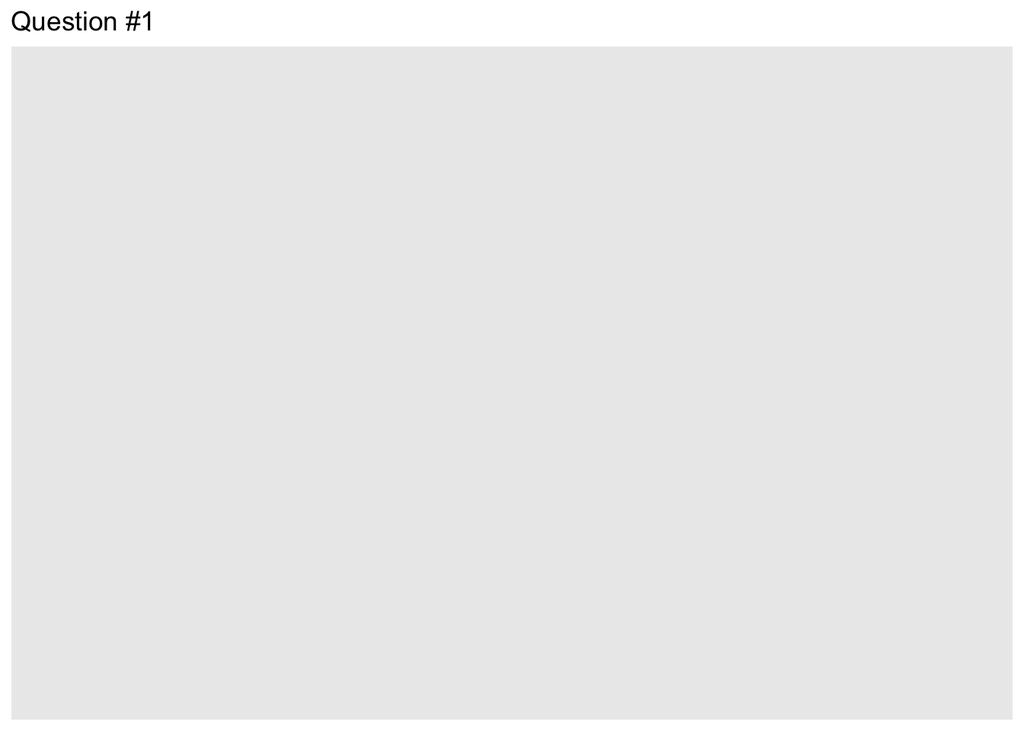

```r
library(ggplot2)
ggplot(data = mpg) + ggtitle("Question #1")
```

```r
mpg
```

```
## # A tibble: 234 x 11
##    manufacturer model displ  year   cyl trans drv     cty   hwy fl    class
##    <chr>        <chr> <dbl> <int> <int> <chr> <chr> <int> <int> <chr> <chr>
##  1 audi         a4      1.8  1999     4 auto… f        18    29 p     comp…
##  2 audi         a4      1.8  1999     4 manu… f        21    29 p     comp…
##  3 audi         a4      2    2008     4 manu… f        20    31 p     comp…
##  4 audi         a4      2    2008     4 auto… f        21    30 p     comp…
##  5 audi         a4      2.8  1999     6 auto… f        16    26 p     comp…
##  6 audi         a4      2.8  1999     6 manu… f        18    26 p     comp…
##  7 audi         a4      3.1  2008     6 auto… f        18    27 p     comp…
##  8 audi         a4 q…   1.8  1999     4 manu… 4        18    26 p     comp…
##  9 audi         a4 q…   1.8  1999     4 auto… 4        16    25 p     comp…
## 10 audi         a4 q…   2    2008     4 manu… 4        20    28 p     comp…
## # … with 224 more rows
```

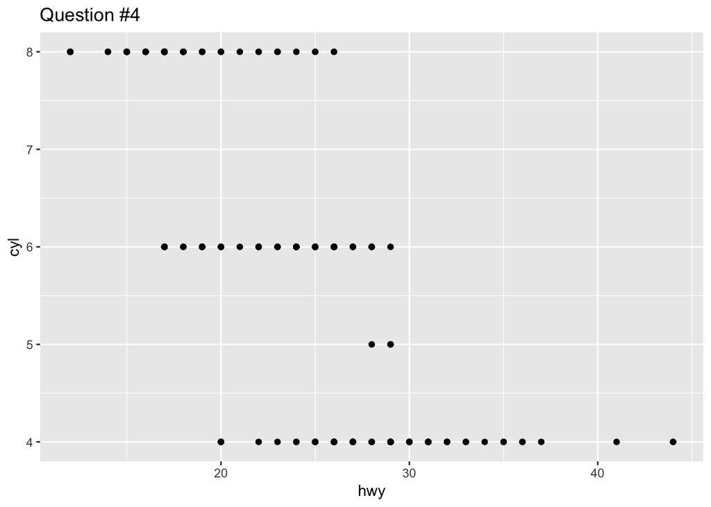

```r
?mpg
ggplot(data = mpg) + geom_point(mapping = aes(x =hwy, y = cyl)) + ggtitle("Question #4")
```

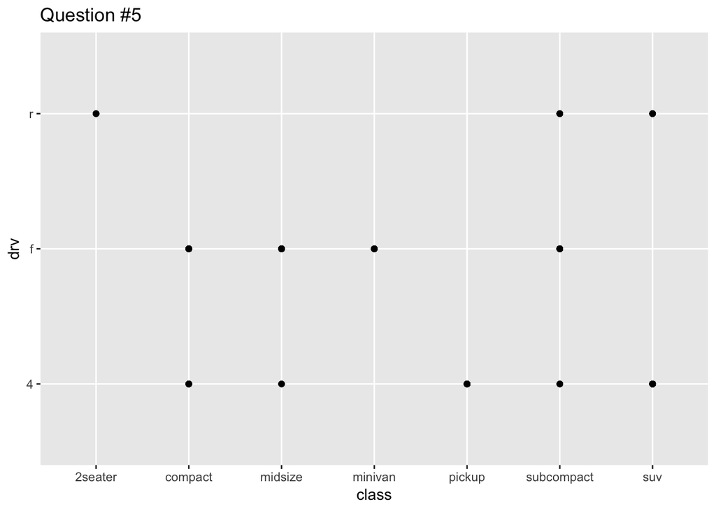

```r
ggplot(data = mpg) + geom_point(mapping = aes(x =class, y = drv)) + ggtitle("Question #5")
```